# Statistical Inference Course Project Part 2

Calvin Seto

September 7, 2015

## Synopsis

Some questions we may want to ask are: Does OJ supplements increase teeth length more than VC supplements? Does 1.0 doses of Vitamin C increase teeth length more than 0.5 doses? Does 2.0 doses of Vitamin C increase teeth length more than 0.5 doses? Does 2.0 doses of Vitamin C increase teeth length more than 1.0 doses?

## Data Exploration

We’ll create the following subsets ssOJ - teeth length of guinea pigs who received orange juice supplements ssVC - teeth length of guinea pigs who received ascorbic acid supplements ssOJ0510 - teeth length of guinea pigs who received dosages of 0.5 and 1 mg using OJ. ssOJ0520 - teeth length of guinea pigs who received dosages of 0.5 and 2 mg using OJ. ssOJ1020 - teeth length of guinea pigs who received dosages of 1 and 2 mg using OJ. ssVC0510 - teeth length of guinea pigs who received dosages of 0.5 and 1 mg using VC. ssVC0520 - teeth length of guinea pigs who received dosages of 0.5 and 2 mg using VC. ssVC1020 - teeth length of guinea pigs who received dosages of 1 and 2 mg using VC.

The mean teeth length for guinea pigs receiving VC supplements is 16.96, while the mean teeth length for guinea pigs receiving OJ supplements is 20.66. The range of mean teeth length for guinea pigs receiving OJ supplements is 8.2 - 30.9 and for those receiving VC supplements is 4.2 - 33.9.

The mean teeth length for guinea pigs receiving doses of 0.5 mg is 10.61, for doses of 1.0 is 19.74, and for doses of 2.0 is 26.10. The range 0.5 len 4.2 - 21.5, range 1.0 len 13.6 - 27.3, and range 2.0 len 18.5 - 33.9.

## Confidence Intervals and tests

conditions for the confidence interval -sampled observations must be independent -sample size n >= 30 or larger if population distribution is skewed -show normal or assume normal When the sample size is small and it’s difficult to confirm normality of the sample distribution, we use the t distribution. It’s always centered at 0 and has the single parameter degrees of freedom. As degrees of freedom increases, the t distribution starts to resemble a normal distribution. For inference on a mean, use t statistic when sample size n < 30 and the standard deviation is unknown.

## unknown population mean can be estimated with the sample mean, t distribution, t statistic, and sample standard deviation which estimates the standard error.

We have samples of VC and OJ.

We have samples of 0.5, 1.0, and 2.0.

Given, sample means, standard deviations, and sample sizes for 2 groups, Estimate the average snack consumption of distracted eaters. Is the amount of snacks consumed by distracted eaters different from the suggested serving size?

## Appendix

Listing 1

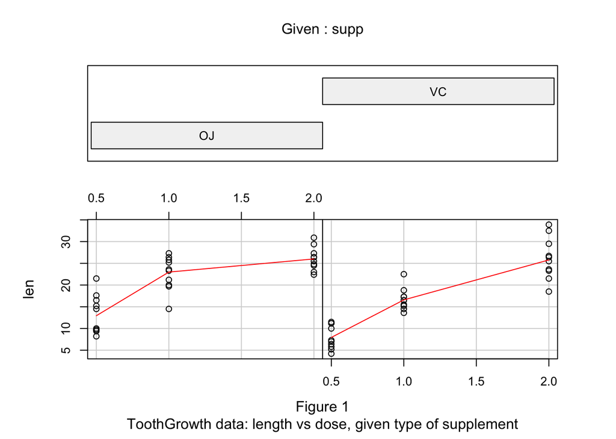

```r
require(graphics)
coplot(len ~ dose | supp, data = ToothGrowth, panel = panel.smooth,
       xlab = "Figure 1\nToothGrowth data: length vs dose, given type of supplement")
```

Listing 2

```r
ssOJ <- subset(ToothGrowth, supp == "OJ")
ssVC <- subset(ToothGrowth, supp == "VC")
ssOJ0510 <- subset(ToothGrowth, supp == "OJ" & (dose == 0.5 | dose == 1))
ssOJ0520 <- subset(ToothGrowth, supp == "OJ" & (dose == 0.5 | dose == 2))
ssOJ1020 <- subset(ToothGrowth, supp == "OJ" & (dose == 1 | dose == 2))
ssVC0510 <- subset(ToothGrowth, supp == "VC" & (dose == 0.5 | dose == 1))
ssVC0520 <- subset(ToothGrowth, supp == "VC" & (dose == 0.5 | dose == 2))
ssVC1020 <- subset(ToothGrowth, supp == "VC" & (dose == 1 | dose == 2))

summary(ToothGrowth)
```

```
##       len        supp         dose
##  Min.   : 4.20   OJ:30   Min.   :0.500
##  1st Qu.:13.07   VC:30   1st Qu.:0.500
##  Median :19.25           Median :1.000
##  Mean   :18.81           Mean   :1.167
##  3rd Qu.:25.27           3rd Qu.:2.000
##  Max.   :33.90           Max.   :2.000
```

```r
summary(ssOJ$len)
```

```
##    Min. 1st Qu.  Median    Mean 3rd Qu.    Max.
##    8.20   15.52   22.70   20.66   25.72   30.90
```

```r
summary(ssVC$len)
```

```
##    Min. 1st Qu.  Median    Mean 3rd Qu.    Max.
##    4.20   11.20   16.50   16.96   23.10   33.90
```

```r
summary(subset(ToothGrowth, supp == "OJ" & dose == 0.5)$len)
```

```
##    Min. 1st Qu.  Median    Mean 3rd Qu.    Max.
##    8.20    9.70   12.25   13.23   16.18   21.50
```

```r
summary(subset(ToothGrowth, supp == "OJ" & dose == 1.0)$len)
```

```
##    Min. 1st Qu.  Median    Mean 3rd Qu.    Max.
##   14.50   20.30   23.45   22.70   25.65   27.30
```

```r
summary(subset(ToothGrowth, supp == "OJ" & dose == 2.0)$len)
```

```
##    Min. 1st Qu.  Median    Mean 3rd Qu.    Max.
##   22.40   24.58   25.95   26.06   27.08   30.90
```

```r
summary(subset(ToothGrowth, supp == "VC" & dose == 0.5)$len)
```

```
##    Min. 1st Qu.  Median    Mean 3rd Qu.    Max.
##    4.20    5.95    7.15    7.98   10.90   11.50
```

```r
summary(subset(ToothGrowth, supp == "VC" & dose == 1.0)$len)
```

```
##    Min. 1st Qu.  Median    Mean 3rd Qu.    Max.
##   13.60   15.27   16.50   16.77   17.30   22.50
```

```r
summary(subset(ToothGrowth, supp == "VC" & dose == 2.0)$len)
```

```
##    Min. 1st Qu.  Median    Mean 3rd Qu.    Max.
##   18.50   23.38   25.95   26.14   28.80   33.90
```

```r
sd(ssOJ$len)
```

```
## [1] 6.605561
```

```r
sd(ssVC$len)
```

```
## [1] 8.266029
```

NOTES compare VC to OJ 30 measures VC 0.5, VC 1.0, VC 2.0 30 measures OJ 0.5, VC 1.0, VC 2.0

compare 0.5 to 1.0 20 measures 0.5 VC and 0.5 OJ 20 measures 1.0 VC and 1.0 OJ

compare 0.5 to 2.0 20 measures 0.5 VC and 0.5 OJ 20 measures 2.0 VC and 2.0 OJ

compare 1.0 to 2.0 20 measures 1.0 VC and 1.0 OJ 20 measures 2.0 VC and 2.0 OJ

population of 60 guinea pigs, divided into 6 groups of 10 group 1 pigs 01-10 VC 0.5 group 2 pigs 11-20 VC 1.0 group 3 pigs 21-30 VC 2.0 group 4 pigs 31-40 OJ 0.5 group 5 pigs 41-50 OJ 1.0 group 6 pigs 51-60 OJ 2.0

after 42 days, pigs were euthanized and the mean length of teeth for each group were measured ToothGrowth dataset 60 obs of 3 variables-len, supp, dose